# drpr-vignette

Neil Diamond

2016-01-25

# Introduction

An R package, drpr, has been built to undertake the DRP calculations in R.

To install the package you use the command “install.packages(‘drpr_0.98.zip’, repos=NULL)”.

You then need to load the package:

```r
library("drpr")
Jan15m <- Jan15[order(Jan15$Maturity),][-1,]
```

Note that Jan15 is an example data file. In the following, I have used Jan15 with the bond with the lowest maturity removed. The user can load his or her own data using say “Dec15 <- read.csv(‘Dec15.csv’)” where the .csv file must have (at least) three numeric columns labelled “Maturity”, “Yield”, and “Amount.issued”.

# No Adjustment for Credit Raings

## Gaussian Smoothing

The underlying Gaussian smoothing is done by the gswt1() function. For convenience, the gkest1() calls the gswt1() function for target terms to maturity of 3, 5, 7, and 10 years. The documentation for the two functions and an Example is given below:

```r
?gswt1
```

| gswt1 | R Documentation |
| --- | --- |

## gswt1

### Description

Local Constant Smoothing

### Usage

```r
gswt1(tt = 10, data = Jan15, sigma = 1.5, ...)
```

### Arguments

| `tt` | Target Tenor |
| --- | --- |
| `data` | Data file consisting of at least 3 columns: Maturity, Amount.issued, and Yield |
| `sigma` | Smoothing Constant |
| `maturity` | Maturity |
| `issue` | Amount issued (should be numeric) |
| `yield` | Yield |

### Value

a list of class “GaussianSmoother”

```r
?gkest1
```

| gkest1 | R Documentation |
| --- | --- |

## gkest

### Description

Interpolated and Extrapolated 7 and 10 year yields

### Usage

```r
gkest1(sigma = 1.5, data = Jan15)
```

### Arguments

| `sigma` | Smoothing Constant |
| --- | --- |
| `data` | Data file consisting of at least 3 columns: Maturity, Amount.issued, and Yield |

### Value

list consisting of a matrix of Target Tenor, sigma, Target Tenor Yield, Effective Term to Maturity, and Annual Yield; Interpolated 7 year yield (Semi-annual basis); Extrapolated 10 year yield (Semi-annual basis); Interpolated 7 year yield (Annual basis); and Extrapolated 10 year yield (Annual basis)

```r
fit0 <- gswt1(data=Jan15m)
print(fit0)
```

```
##               Target Tenor                      Sigma
##                  10.000000                   1.500000
##         Target Tenor Yield Effective Term to Maturity
##                   4.365171                   8.523605
```

```r
summary(fit0)
```

```
## $`Annualized Yields`
##   Tenor Sigma SemiAnnYield EffectiveTenor AnnYield
## 1     3   1.5       3.9762         3.9903   4.0157
## 2     5   1.5       4.2135         5.2397   4.2579
## 3     7   1.5       4.4960         6.6277   4.5466
## 4    10   1.5       4.3652         8.5236   4.4128
##
## $`Interpolated 7 year Yield (Semi-annual basis)`
## [1] 4.4703
##
## $`Extrapolated 10 year Yield (Semi-annual basis)`
## [1] 4.2633
##
## $`Interpolated 7 year Yield (Annualized Basis)`
## [1] 4.5203
##
## $`Extrapolated 10 year Yield (Annualized Basis)`
## [1] 4.3087
```

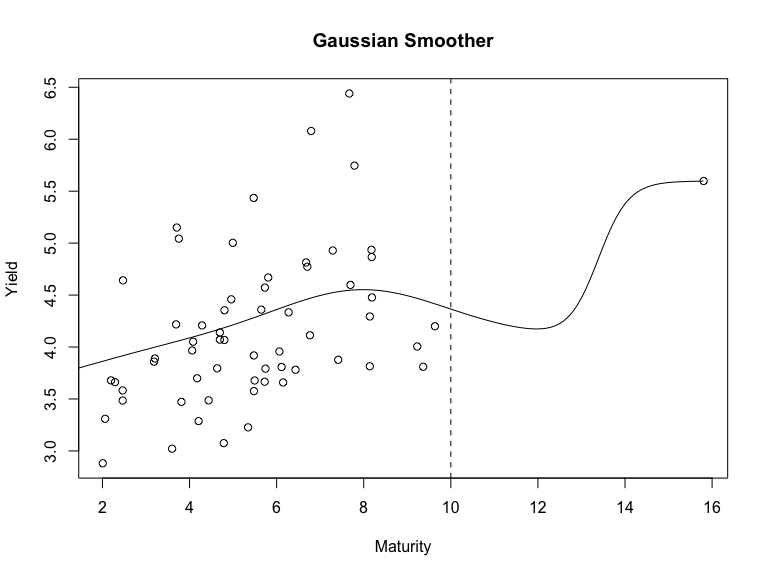

```r
plot(fit0)
```

## Fitting the Nelson-Siegel model

The Nelson-Siegel model is fitted using the fitnelsonsiegel() function. Be default, the starting value for the decay factor is 0.7173, which is the value maximising the loading of the curvature factor for a maturity of 2.5 years.

```r
library(drpr)
library(minpack.lm)
?fitnelsonsiegel
```

| fitnelsonsiegel | R Documentation |
| --- | --- |

## Fit the Nelson-Siegel model

### Description

Fit the Nelson-Siegel model

### Usage

```r
fitnelsonsiegel(data, lambdastartval = lambdastart(2.5), epsilon = 1e-14)
```

### Arguments

| `data` | data file with at least columns named Yield and Maturity |
| --- | --- |
| `lambdastartval` | starting value for lambda in Nelson-Siegel model |
| `epsilon` | a small value to prevent -Inf when taking log of zero |

### Value

A NelsonSiegel object

```r
fitnelsonsiegel(Jan15m)
```

```
## Nonlinear regression model
##   model: Yield ~ exp(delta1) + (exp(delta2) - exp(delta1)) * (1 - exp(-Maturity *     (exp(gamma))))/(Maturity * (exp(gamma))) + delta3 * ((1 -     exp(-Maturity * (exp(gamma))))/(Maturity * (exp(gamma))) -     exp(-Maturity * (exp(gamma))))
##    data: DF
##    delta1    delta2    delta3     gamma
##  1.947737  1.128049 -0.007872 -2.045241
##  residual sum-of-squares: 25.14
##
## Number of iterations to convergence: 14
## Achieved convergence tolerance: 1.49e-08
```

```r
fit1 <- fitnelsonsiegel(Jan15m)
print(fit1)
```

```
## Nonlinear regression model
##   model: Yield ~ exp(delta1) + (exp(delta2) - exp(delta1)) * (1 - exp(-Maturity *     (exp(gamma))))/(Maturity * (exp(gamma))) + delta3 * ((1 -     exp(-Maturity * (exp(gamma))))/(Maturity * (exp(gamma))) -     exp(-Maturity * (exp(gamma))))
##    data: DF
##    delta1    delta2    delta3     gamma
##  1.947737  1.128049 -0.007872 -2.045241
##  residual sum-of-squares: 25.14
##
## Number of iterations to convergence: 14
## Achieved convergence tolerance: 1.49e-08
```

```
## $`Original Parameters`
##        beta1        beta2        beta3       lambda
##  7.012801314 -3.923179241 -0.007871605  0.129349014
##
## $`Ten Year Yield (Semi-Annual Basis)`
## [1] 4.809519
##
## $`Ten Year Yield (Annual Basis)`
## [1] 4.867347
```

```r
summary(fit1)
```

```
## $`Fitted Nelson-Siegel Model`
##
## Formula: Yield ~ exp(delta1) + (exp(delta2) - exp(delta1)) * (1 - exp(-Maturity *
##     (exp(gamma))))/(Maturity * (exp(gamma))) + delta3 * ((1 -
##     exp(-Maturity * (exp(gamma))))/(Maturity * (exp(gamma))) -
##     exp(-Maturity * (exp(gamma))))
##
## Parameters:
##          Estimate Std. Error t value Pr(>|t|)
## delta1  1.948e+00  3.645e+00   0.534  0.59514
## delta2  1.128e+00  3.798e-01   2.970  0.00436 **
## delta3 -7.872e-03  1.372e+04   0.000  1.00000
## gamma  -2.045e+00  3.508e+03  -0.001  0.99954
## ---
## Signif. codes:  0 '***' 0.001 '**' 0.01 '*' 0.05 '.' 0.1 ' ' 1
##
## Residual standard error: 0.6641 on 57 degrees of freedom
##
## Number of iterations to convergence: 14
## Achieved convergence tolerance: 1.49e-08
##
##
## $`Original Parameters`
##        beta1        beta2        beta3       lambda
##  7.012801314 -3.923179241 -0.007871605  0.129349014
##
## $`Ten Year Yield (Semi-Annual Basis)`
## [1] 4.809519
##
## $`Ten Year Yield (Annual Basis)`
## [1] 4.867347
```

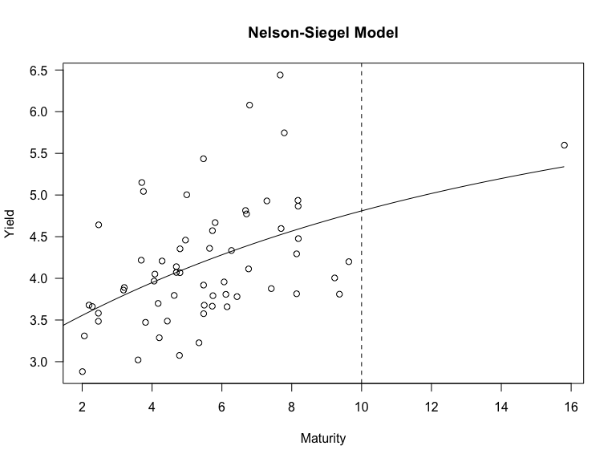

```r
plot(fit1)
```

## Fitting the Nelson-Siegel-Svensson model

The Nelson-Siegel-Svensson model is fitted using the fitnelsonsiegelsvensson() function. Be default, the starting value for the two decay factors maximise the loading of the curvature factor for a maturity of 2.5 years and a maturity of 5 years. However, note well, the inverse decay factors are used.

```r
?fitnelsonsiegelsvensson
```

| fitnelsonsiegelsvensson | R Documentation |
| --- | --- |

## Fit the Nelson-Siegel-Svensson model

### Description

Fit the Nelson-Siegel-Svensson model

### Usage

```r
fitnelsonsiegelsvensson(data, lambda1start = 1/lambdastart(2.5),
  lambda2start = 1/lambdastart(5), epsilon = 1e-14)
```

### Arguments

| `data` | data file with at least columns named Yield and Maturity |
| --- | --- |
| `lambda1start` | starting value for lambda1 |
| `lambda2start` | starting value for lambda2; lambda2 > lambda1 |
| `epsilon` | a small value to prevent -Inf when taking log of zero |

### Value

A NelsonSiegelSvensson object

```r
fitnelsonsiegelsvensson(Jan15, lambda1start=1/lambdastart(2.5),
                               lambda2start=1/lambdastart(5))
```

```
## Nonlinear regression model
##   model: Yield ~ exp(delta1) + (exp(delta2) - exp(delta1)) * (1 - exp(-Maturity/(exp(gamma1))))/(Maturity/(exp(gamma1))) +     delta3 * ((1 - exp(-Maturity/(exp(gamma1))))/(Maturity/(exp(gamma1))) -         exp(-Maturity/(exp(gamma1)))) + delta4 * ((1 - exp(-Maturity/(exp(gamma2) +     exp(gamma1…
##    data: data
##    delta1    delta2    delta3    delta4    gamma1    gamma2
##     1.937     6.907 -1014.055    -6.538    -1.618     1.076
##  residual sum-of-squares: 25.04
##
## Number of iterations till stop: 275
## Achieved convergence tolerance: 1.49e-08
## Reason stopped: Number of calls to `fcn' has reached or exceeded `maxfev' == 2000.
```

```r
fit2 <- fitnelsonsiegelsvensson(Jan15m, lambda1start=1/lambdastart(2.5),
                               lambda2start=1/lambdastart(5))
print(fit2)
```

```
## Nonlinear regression model
##   model: Yield ~ exp(delta1) + (exp(delta2) - exp(delta1)) * (1 - exp(-Maturity/(exp(gamma1))))/(Maturity/(exp(gamma1))) +     delta3 * ((1 - exp(-Maturity/(exp(gamma1))))/(Maturity/(exp(gamma1))) -         exp(-Maturity/(exp(gamma1)))) + delta4 * ((1 - exp(-Maturity/(exp(gamma2) +     exp(gamma1…
##    data: data
##   delta1   delta2   delta3   delta4   gamma1   gamma2
##   1.8257 -15.7989  85.8643 -84.7073   0.3668  -2.5005
##  residual sum-of-squares: 25.03
##
## Number of iterations to convergence: 124
## Achieved convergence tolerance: 1.49e-08
```

```
## $`Original Parameters`
##      beta1      beta2      beta3      beta4    lambda1    lambda2
##   6.207240  -6.207240  85.864257 -84.707304   1.443113   1.525160
##
## $`Ten Year Yield (Semi-Annual Basis)`
## [1] 4.826845
##
## $`Ten Year Yield (Annual Basis)`
## [1] 4.885091
```

```r
summary(fit2)
```

```
## $`Fitted Nelson-Siegel-Svensson Model`
##
## Formula: Yield ~ exp(delta1) + (exp(delta2) - exp(delta1)) * (1 - exp(-Maturity/(exp(gamma1))))/(Maturity/(exp(gamma1))) +
##     delta3 * ((1 - exp(-Maturity/(exp(gamma1))))/(Maturity/(exp(gamma1))) -
##         exp(-Maturity/(exp(gamma1)))) + delta4 * ((1 - exp(-Maturity/(exp(gamma2) +
##     exp(gamma1))))/(Maturity/(exp(gamma2) + exp(gamma1))) - exp(-Maturity/(exp(gamma2) +
##     exp(gamma1))))
##
## Parameters:
##          Estimate Std. Error t value Pr(>|t|)
## delta1  1.826e+00  4.837e-01   3.774 0.000395 ***
## delta2 -1.580e+01  1.135e+07   0.000 0.999999
## delta3  8.586e+01  2.175e+05   0.000 0.999686
## delta4 -8.471e+01  2.170e+05   0.000 0.999690
## gamma1  3.668e-01  6.991e+01   0.005 0.995833
## gamma2 -2.501e+00  2.549e+03  -0.001 0.999221
## ---
## Signif. codes:  0 '***' 0.001 '**' 0.01 '*' 0.05 '.' 0.1 ' ' 1
##
## Residual standard error: 0.6746 on 55 degrees of freedom
##
## Number of iterations to convergence: 124
## Achieved convergence tolerance: 1.49e-08
##
##
## $`Original Parameters`
##      beta1      beta2      beta3      beta4    lambda1    lambda2
##   6.207240  -6.207240  85.864257 -84.707304   1.443113   1.525160
##
## $`Ten Year Yield (Semi-Annual Basis)`
## [1] 4.826845
##
## $`Ten Year Yield (Annual Basis)`
## [1] 4.885091
```

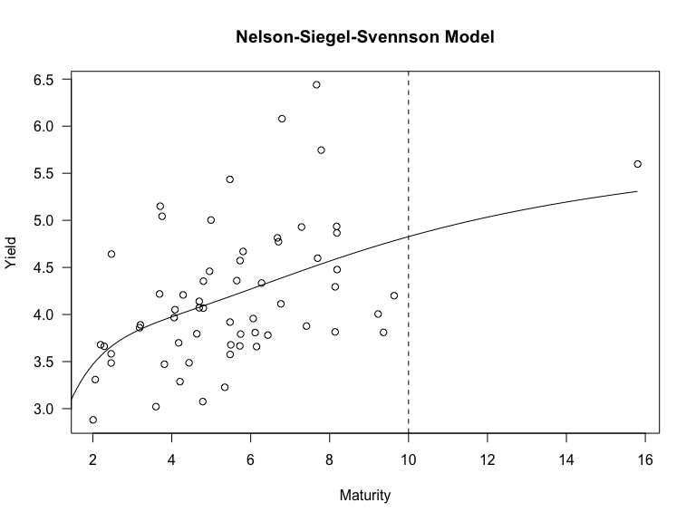

```r
plot(fit2)
```

## Obtaining the DRP

```r
?drp
```

| drp | R Documentation |
| --- | --- |

## drp

### Description

Determine Debt Risk Premium

### Usage

```r
drp(GSmodel10, NSmodel, NSSmodel, avspotratesa)
```

### Arguments

| `GSmodel10` | a GaussianSmooth object |
| --- | --- |
| `NSmodel` | a NelsonSiegel object |
| `NSSmodel` | a NelsonSiegelSvensson object |
| `avspotratesa` | average swap rates (semi-annual basis) |

### Value

list consisting of Average Swap rate (semi-annual basis), Annualized Swap average, 10 year final cost of debt estimate“,”10 year DRP"

```r
drp(fit0, fit1, fit2, avspotratesa=2.9546)
```

```
## $`Average swap rate (semi-annual basis)`
## [1] 2.9546
##
## $`Annualized Swap average (annual basis)`
## [1] 2.9764
##
## $`10 year final cost of debt estimate`
## (Intercept)
##      4.6672
##
## $`10 year DRP`
## (Intercept)
##      1.6908
```

## Comparisons

The package can be used to make graphical comparisons between the three techniques:

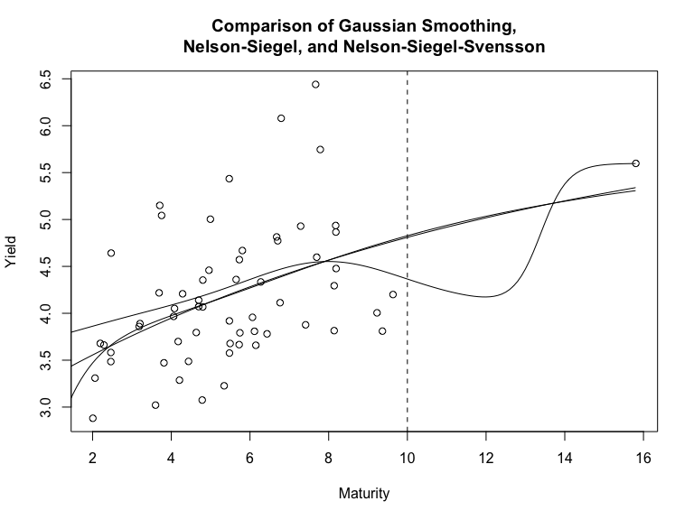

```r
drpplot(fit0, fit1, fit2)
```

# Adjusting for Credit Raings

A major shortcoming of the calculations above is that they do not adjust for credit ratings. Additional functions are provided that do this adjustment.

## Gaussian Smoothing

The function gswt1adjust() adjusts for credit ratings using the technique of backfitting. This is an iterative technique: First the credit ratings are ignored and the usual Gaussian Kernel is applied. Then a linear model is fitted to the residuals and the fitted model is used to adjust for the credit ratings. The process is continued until convergence. In most case only a small number of iterations are required.

```r
?gswt1adjust
```

| gswt1adjust | R Documentation |
| --- | --- |

## gswt1adjust

### Description

Local Constant Smoothing adjusted for Credit ratings

### Usage

```r
gswt1adjust(tt = 10, data = Jan15, sigma = 1.5)
```

### Arguments

| `tt` | Target Tenor |
| --- | --- |
| `data` | Data file consisting of at least 3 columns: Maturity, Amount.issued, and Yield |
| `sigma` | Smoothing Constant |
| `maturity` | Maturity |
| `issue` | Amount issued |
| `yield` | Yield |

### Value

a list of class “GaussianSmoothAdjust”

```r
?gkest1adjust
```

| gkest1adjust | R Documentation |
| --- | --- |

## gkest

### Description

Interpolated and Extrapolated 7 and 10 year yields adjusting for Credit ratings

### Usage

```r
gkest1adjust(sigma = 1.5, data)
```

### Arguments

| `sigma` | Smoothing Constant |
| --- | --- |
| `filename` | Data file consisting of at least 3 columns: Maturity, Amount.issued, and Yield |

### Value

list consisting of a matrix of Target Tenor, sigma, Target Tenor Yield, Effective Term to Maturity, and Annual Yield; Interpolated 7 year yield (Semi-annual basis); Extrapolated 10 year yield (Semi-annual basis); Interpolated 7 year yield (Annual basis); and Extrapolated 10 year yield (Annual basis)

```r
fit3 <- gswt1adjust(data=Jan15m)
```

```r
print(fit3)
```

```
##               Target Tenor                      Sigma
##                  10.000000                   1.500000
##         Target Tenor Yield Effective Term to Maturity
##                   4.465772                   8.523605
```

```r
summary(fit3)
```

```
## $`Annualized Yields`
##   Tenor Sigma SemiAnnYield EffectiveTenor AnnYield
## 1     3   1.5       4.0465         3.9903   4.0874
## 2     5   1.5       4.2838         5.2397   4.3297
## 3     7   1.5       4.5663         6.6277   4.6185
## 4    10   1.5       4.4355         8.5236   4.4847
##
## $`Interpolated 7 year Yield (Semi-annual basis)`
## [1] 4.5406
##
## $`Extrapolated 10 year Yield (Semi-annual basis)`
## [1] 4.3336
##
## $`Interpolated 7 year Yield (Annualized Basis)`
## [1] 4.5922
##
## $`Extrapolated 10 year Yield (Annualized Basis)`
## [1] 4.3805
```

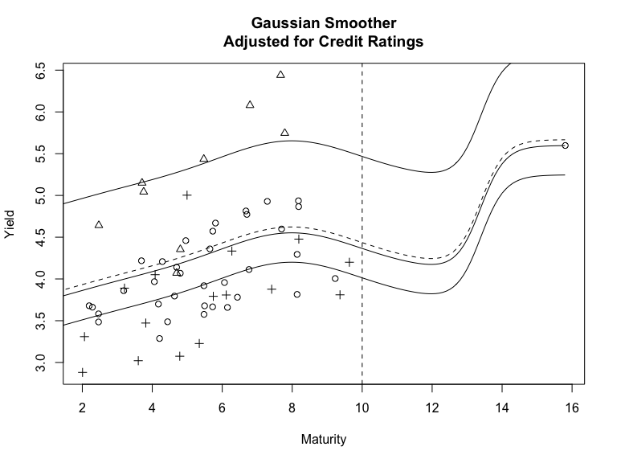

```r
plot(fit3)
```

## Fitting the Nelson-Siegel model

The model allows the level parameter to depend on the credit rating but the other parameters are constrained to be the same.

```r
library(drpr)
library(minpack.lm)
?fitnelsonsiegeladjust
```

| fitnelsonsiegeladjust | R Documentation |
| --- | --- |

## Fit the Nelson-Siegel model adjusting for Credit ratings

### Description

Fit the Nelson-Siegel model adjusting for Credit ratings

### Usage

```r
fitnelsonsiegeladjust(data, lambdastartval = lambdastart(2.5),
  epsilon = 1e-14)
```

### Arguments

| `data` | data file with at least columns named Yield and Maturity and Credit rating |
| --- | --- |
| `lambdastartval` | starting value for lambda in Nelson-Siegel model |
| `epsilon` | a small value to prevent -Inf when taking log of zero |

### Value

A NelsonSiegelAdjust object

```r
fit4 <- fitnelsonsiegeladjust(Jan15m)
```

```r
print(fit4)
```

```
## Nonlinear regression model
##   model: Yield ~ exp(delta1) + (exp(delta2) - exp(delta1)) * (1 - exp(-Maturity *     (exp(gamma))))/(Maturity * (exp(gamma))) + delta3 * ((1 -     exp(-Maturity * (exp(gamma))))/(Maturity * (exp(gamma))) -     exp(-Maturity * (exp(gamma)))) + exp(theta1) * (BBB + BBBm) +     exp(theta2) * BBBm
##    data: DF
##   delta1   delta2   delta3    gamma   theta1   theta2
##  2.30303  1.03096  0.05532 -2.90571 -1.21249  0.16458
##  residual sum-of-squares: 11.84
##
## Number of iterations to convergence: 26
## Achieved convergence tolerance: 1.49e-08
```

```
## $`Original Parameters`
##       beta1       beta2       beta3      lambda       beta5       beta6
## 10.00449484 -7.20073373  0.05532304  0.05471005  1.17889551 -0.29745539
##
## $`Ten Year Yield (Semi-Annual Basis)`
## [1] 4.862483
##
## $`Ten Year Yield (Annual Basis)`
## [1] 4.921592
```

```r
summary(fit4)
```

```
## $`Fitted Nelson-Siegel Model`
##
## Formula: Yield ~ exp(delta1) + (exp(delta2) - exp(delta1)) * (1 - exp(-Maturity *
##     (exp(gamma))))/(Maturity * (exp(gamma))) + delta3 * ((1 -
##     exp(-Maturity * (exp(gamma))))/(Maturity * (exp(gamma))) -
##     exp(-Maturity * (exp(gamma)))) + exp(theta1) * (BBB + BBBm) +
##     exp(theta2) * BBBm
##
## Parameters:
##          Estimate Std. Error t value Pr(>|t|)
## delta1  2.303e+00  2.310e+01   0.100   0.9209
## delta2  1.031e+00  2.367e-01   4.356 5.84e-05 ***
## delta3  5.532e-02  2.142e+04   0.000   1.0000
## gamma  -2.906e+00  2.922e+03  -0.001   0.9992
## theta1 -1.212e+00  4.746e-01  -2.555   0.0134 *
## theta2  1.646e-01  1.472e-01   1.118   0.2686
## ---
## Signif. codes:  0 '***' 0.001 '**' 0.01 '*' 0.05 '.' 0.1 ' ' 1
##
## Residual standard error: 0.464 on 55 degrees of freedom
##
## Number of iterations to convergence: 26
## Achieved convergence tolerance: 1.49e-08
##
##
## $`Original Parameters`
##       beta1       beta2       beta3      lambda       beta5       beta6
## 10.00449484 -7.20073373  0.05532304  0.05471005  1.17889551 -0.29745539
##
## $`Ten Year Yield (Semi-Annual Basis)`
## [1] 4.862483
##
## $`Ten Year Yield (Annual Basis)`
## [1] 4.921592
```

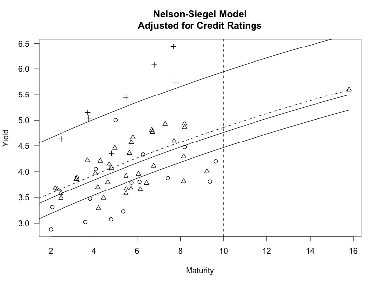

```r
plot(fit4)
```

## Fitting the Nelson-Siegel-Svensson model

The model allows the level parameter to depend on the credit rating but the other parameters are constrained to be the same.

```r
?fitnelsonsiegelsvenssonadjust
```

| fitnelsonsiegelsvenssonadjust | R Documentation |
| --- | --- |

## Fit the Nelson-Siegel-Svensson model adjusting for Credit ratings

### Description

Fit the Nelson-Siegel-Svensson model adjusting for Credit ratings

### Usage

```r
fitnelsonsiegelsvenssonadjust(data, lambda1start = 1/lambdastart(2.5),
  lambda2start = 1/lambdastart(5), epsilon = 1e-14)
```

### Arguments

| `data` | data file with at least columns named Yield and Maturity |
| --- | --- |
| `epsilon` | a small value to prevent -Inf when taking log of zero |
| `loglambda1start` | starting value for log(lambda1) in Nelson-Siegel-Svensson model |
| `loglambda2start` | starting value for log(lambda2) in Nelson-Siegel-Svensson model |

### Value

A NelsonSiegelSvenssonAdjust object

```r
fit5 <- fitnelsonsiegelsvenssonadjust(Jan15m, lambda1start=1/lambdastart(2.5),
                               lambda2start=1/lambdastart(5))
print(fit5)
```

```
## Nonlinear regression model
##   model: Yield ~ exp(delta1) + (exp(delta2) - exp(delta1)) * (1 - exp(-Maturity/(exp(gamma1))))/(Maturity/(exp(gamma1))) +     delta3 * ((1 - exp(-Maturity/(exp(gamma1))))/(Maturity/(exp(gamma1))) -         exp(-Maturity/(exp(gamma1)))) + delta4 * ((1 - exp(-Maturity/(exp(gamma2) +     exp(gamma1…
##    data: DF
##     delta1     delta2     delta3     delta4     gamma1     gamma2
##     7.0901     1.5879  -449.9540 -2968.7763     1.6625     2.7249
##     theta1     theta2
##    -1.2918     0.1751
##  residual sum-of-squares: 11.53
##
## Number of iterations till stop: 1024
## Achieved convergence tolerance: 1.49e-08
## Reason stopped: Number of iterations has reached `maxiter' == 1024.
```

```
## $`Original parameters`
##         beta1         beta2         beta3         beta4       lambda1
##  1200.0130266 -1195.1196383  -449.9539726 -2968.7763297     5.2723673
##       lambda2         beta5         beta6
##    20.5269611     1.1913565    -0.2747627
##
## $`Ten Year Yield (Semi-Annual Basis)`
## [1] 4.594369
##
## $`Ten Year Yield (Annual Basis)`
## [1] 4.64714
```

```r
summary(fit5)
```

```
## $`Fitted Nelson-Siegel-Svensson Model`
##
## Formula: Yield ~ exp(delta1) + (exp(delta2) - exp(delta1)) * (1 - exp(-Maturity/(exp(gamma1))))/(Maturity/(exp(gamma1))) +
##     delta3 * ((1 - exp(-Maturity/(exp(gamma1))))/(Maturity/(exp(gamma1))) -
##         exp(-Maturity/(exp(gamma1)))) + delta4 * ((1 - exp(-Maturity/(exp(gamma2) +
##     exp(gamma1))))/(Maturity/(exp(gamma2) + exp(gamma1))) - exp(-Maturity/(exp(gamma2) +
##     exp(gamma1)))) + exp(theta1) * (BBB + BBBm) + exp(theta2) *
##     BBBm
##
## Parameters:
##          Estimate Std. Error t value Pr(>|t|)
## delta1     7.0901    21.5883   0.328   0.7439
## delta2     1.5879     1.2750   1.245   0.2184
## delta3  -449.9540  8558.7632  -0.053   0.9583
## delta4 -2968.7763 63065.3535  -0.047   0.9626
## gamma1     1.6625     6.2971   0.264   0.7928
## gamma2     2.7249     4.1844   0.651   0.5177
## theta1    -1.2918     0.5328  -2.424   0.0188 *
## theta2     0.1751     0.1477   1.185   0.2412
## ---
## Signif. codes:  0 '***' 0.001 '**' 0.01 '*' 0.05 '.' 0.1 ' ' 1
##
## Residual standard error: 0.4664 on 53 degrees of freedom
##
## Number of iterations till stop: 1024
## Achieved convergence tolerance: 1.49e-08
## Reason stopped: Number of iterations has reached `maxiter' == 1024.
##
##
## $`Original Parameters`
##         beta1         beta2         beta3         beta4       lambda1
##  1200.0130266 -1195.1196383  -449.9539726 -2968.7763297     5.2723673
##       lambda2         beta5         beta6
##    20.5269611     1.1913565    -0.2747627
##
## $`Ten Year Yield (Semi-Annual Basis)`
## [1] 4.594369
##
## $`Ten Year Yield (Annual Basis)`
## [1] 4.64714
```

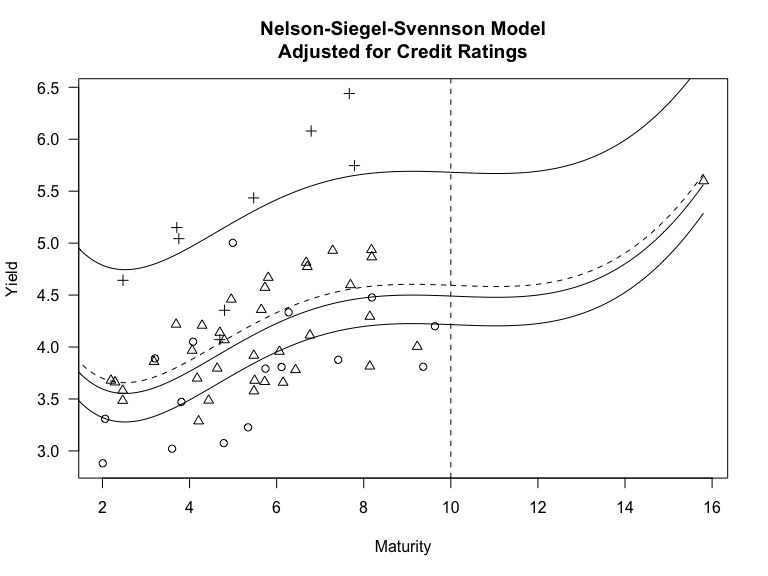

```r
plot(fit5)
```

## Obtaining the DRP

The three results are combined.

```r
?drpadjust
```

| drpadjust | R Documentation |
| --- | --- |

## drpadjust

### Description

Determine Debt Risk Premium adjusted for Credit ratings

### Usage

```r
drpadjust(GSadjustmodel10, NSadjustmodel, NSSadjustmodel, avspotratesa)
```

### Arguments

| `avspotratesa` | average swap rates (semi-annual basis) |
| --- | --- |
| `data` | Data file consisting of at least 4 columns: Maturity, Amount.issued, Yield, and Credit.rating |
| `GSmodel10` | a GaussianSmooth object |
| `NSmodel` | a NelsonSiegel object |
| `NSSmodel` | a NelsonSiegelSvensson object |

### Value

list consisting of Average Swap rate (semi-annual basis), Annualized Swap average, 10 year final cost of debt estimate“,”10 year DRP"

```r
drpadjust(fit3,fit4,fit5, avspotratesa=2.9546)
```

```
## $`Average swap rate (semi-annual basis)`
## [1] 2.9546
##
## $`Annualized Swap average (annual basis)`
## [1] 2.9764
##
## $`10 year final cost of debt estimate`
## (Intercept)
##      4.6409
##
## $`10 year DRP`
## (Intercept)
##      1.6645
```

# The code

```r
gswt1
```

```
## function (tt = 10, data=Jan15, sigma = 1.5, ...){
##     maturity <- data$Maturity
##     issue <- data$Amount.issued
##     yield <- data$Yield
##     w <- issue * dnorm(maturity, tt, sigma)
##     w <- w/sum(w)
##     reg1 <- lm(maturity ~ 1, weights = w, model=T)
##     reg2 <- lm(yield ~ 1, weights = w, model=T)
##     result <- list(reg1, reg2, tt, sigma, data)
##     class(result) <- "GaussianSmooth"
##     return(result)
##   }
## <environment: namespace:drpr>
```

```r
gkest1
```

```
## function(sigma=1.5, data=Jan15){
##   gswt0 <-
##     function (tt = 10, data=data, sigma = sigma, ...){
##       maturity <- data$Maturity
##       issue <- data$Amount.issued
##       yield <- data$Yield
##       w <- issue * dnorm(maturity, tt, sigma)
##       w <- w/sum(w)
##       reg1 <- lm(maturity ~ 1, weights = w, model=T)
##       reg2 <- lm(yield ~ 1, weights = w, model=T)
##       result <- c(tt,sigma, coef(reg2), coef(reg1))
##       names(result) <- c("Target Tenor","Sigma","Target Tenor Yield","Effective Term to Maturity")
##       return(result)
##     }
##   interpmat <- t(sapply(c(3,5,7,10), gswt0,
##                         sigma=sigma, data=data))
##   interpmat <- as.data.frame(interpmat)
##   colnames(interpmat) <- c("Tenor","Sigma","SemiAnnYield","EffectiveTenor")
##   AnnYield <- ((1+interpmat[,3]/200)^2-1)*100
##   Interp7yrYield <- interpmat[3,3]+
##     (interpmat[4,3]-interpmat[3,3])/(interpmat[4,4]-interpmat[3,4])*(7-interpmat[3,4])
##   Extrap10yrYield <- interpmat[3,3]+
##     (interpmat[4,3]-interpmat[3,3])/(interpmat[4,4]-interpmat[3,4])*(10-interpmat[3,4])
##   Interp7yrYield_ann <- ((1+Interp7yrYield/200)^2-1)*100
##   Extrap10yrYield_ann <- ((1+Extrap10yrYield/200)^2-1)*100
##   AnnYieldMat <- cbind(interpmat, AnnYield)
##   results <- list(round(AnnYieldMat,4), round(Interp7yrYield,4), round(Extrap10yrYield,4),
##                   round(Interp7yrYield_ann,4), round(Extrap10yrYield_ann, 4))
##   names(results) <- c("Annualized Yields", "Interpolated 7 year Yield (Semi-annual basis)",
##                       "Extrapolated 10 year Yield (Semi-annual basis)",
##                       "Interpolated 7 year Yield (Annualized Basis)",
##                       "Extrapolated 10 year Yield (Annualized Basis)")
##   return(results)
## }
## <environment: namespace:drpr>
```

```r
getS3method("print", "GaussianSmooth")
```

```
## function(obj, ...){
##   result <- c(obj[[3]], obj[[4]], coef(obj[[2]]), coef(obj[[1]]))
##   names(result) <- c("Target Tenor", "Sigma", "Target Tenor Yield",
##                      "Effective Term to Maturity")
##   return(result)
## }
## <environment: namespace:drpr>
```

```r
getS3method("summary", "GaussianSmooth")
```

```
## function(obj, ...){
##   gett.GS <- function(obj){
##     c(obj[[3]],obj[[4]],coef(obj[[2]]),coef(obj[[1]]))
##   }
##   interpmat <- matrix(NA, 4, 4)
##   interpmat[1,] <- gett.GS(gswt1(3,
##                                  data=obj[[5]]))
##   interpmat[2,] <- gett.GS(gswt1(5,
##                                  data=obj[[5]]))
##   interpmat[3,] <- gett.GS(gswt1(7,
##                                  data=obj[[5]]))
##   interpmat[4,] <- gett.GS(gswt1(10,
##                                  data=obj[[5]]))
##   interpmat <- as.data.frame(interpmat)
##   colnames(interpmat) <- c("Tenor","Sigma","SemiAnnYield","EffectiveTenor")
##   AnnYield <- ((1+interpmat[,3]/200)^2-1)*100
##   Interp7yrYield <- interpmat[3,3]+
##     (interpmat[4,3]-interpmat[3,3])/(interpmat[4,4]-interpmat[3,4])*(7-interpmat[3,4])
##   Extrap10yrYield <- interpmat[3,3]+
##     (interpmat[4,3]-interpmat[3,3])/(interpmat[4,4]-interpmat[3,4])*(10-interpmat[3,4])
##   Interp7yrYield_ann <- ((1+Interp7yrYield/200)^2-1)*100
##   Extrap10yrYield_ann <- ((1+Extrap10yrYield/200)^2-1)*100
##   AnnYieldMat <- cbind(interpmat, AnnYield)
##   results <- list(round(AnnYieldMat,4), round(Interp7yrYield,4), round(Extrap10yrYield,4),
##                   round(Interp7yrYield_ann,4), round(Extrap10yrYield_ann, 4))
##   names(results) <- c("Annualized Yields", "Interpolated 7 year Yield (Semi-annual basis)",
##                       "Extrapolated 10 year Yield (Semi-annual basis)",
##                       "Interpolated 7 year Yield (Annualized Basis)",
##                       "Extrapolated 10 year Yield (Annualized Basis)")
##   results
## }
## <environment: namespace:drpr>
```

```r
getS3method("plot", "GaussianSmooth")
```

```
## function(obj, ...){
##   plot(obj[[1]]$model$maturity,obj[[2]]$model$yield, xlab="Maturity", ylab="Yield",
##        main="Gaussian Smoother")
##   xx <- seq(0.1,max(obj[[1]]$model$maturity),0.1)
##   yy <- unlist(sapply(sapply(lapply(xx,gswt1,data=obj[[5]]),"[",2),"[",1))
##   invisible(lines(xx,yy))
##   abline(v=10,lty=2)
## }
## <environment: namespace:drpr>
```

```r
lambdastart
```

```
## function(maturity=2.5){
##   beta2 <- function(lam){
##     ((1-exp(-maturity*lam))/(maturity*lam)-exp(-maturity*lam))
##   }
##   optimize(f=beta2, interval=c(10^(-6),10^(6),1000), maximum=T)$maximum
## }
## <environment: namespace:drpr>
```

```r
fitnelsonsiegel
```

```
## function(data, lambdastartval=lambdastart(2.5),
##                                      epsilon=1E-14){
##   lambda <- lambdastartval
##   DF <- data
##   y <- DF$Yield
##   Z <- DF$Maturity*lambda
##   F0 <- 1-(1-exp(-Z))/Z
##   F1 <- (1-exp(-Z))/Z
##   F2 <- ((1-exp(-Z))/Z-exp(-Z))
##   xx1 <- nnnpls(cbind(F0,F1,F2),DF$Yield,c(1,1,-1))
##   xx2 <- nnnpls(cbind(F0,F1,F2),DF$Yield,c(1,1,1))
##   mindeviance=c(deviance(xx1),deviance(xx2))
##   eval(parse(text=paste0("svA <- coef(xx",which.min(mindeviance),")")))
##   fitorig1 <- nlsLM(Yield~ exp(delta1) + (exp(delta2)-exp(delta1)) * (1-exp(-Maturity*(exp(gamma)))) /
##                       (Maturity*(exp(gamma))) +
##                       delta3 * ((1-exp(-Maturity*(exp(gamma)))) /
##                                   (Maturity*(exp(gamma)))-
##                                   exp(-Maturity*(exp(gamma)))),
##                     data=DF,
##                     start=list(delta1=log(svA[1]+epsilon),
##                                delta2=log(svA[2]+epsilon),
##                                delta3=svA[3],
##                                gamma=log(lambdastartval)),
##                     control=nls.lm.control(maxiter=1000,maxfev=2000), trace=F,model=T)
##   class(fitorig1) <- c("NelsonSiegel","nls")
##   return(fitorig1)
## }
## <environment: namespace:drpr>
```

```r
getS3method("print", "NelsonSiegel")
```

```
## function(obj){
##   transformns <- function(obj){
##     cc <- coef(obj)
##     tt <- cc
##     tt[1] <- exp(cc[1]); tt[2] <- exp(cc[2])-exp(cc[1])
##     tt[4] <- exp(cc[4]);
##     names(tt) <- c("beta1","beta2","beta3","lambda")
##     return(tt)
##   }
##
##   x <- predict(obj, newdata=data.frame(Maturity=10))[1]
##   p <- getFromNamespace("print.nls","stats")(obj)
##   r <- list(transformns(obj),x,((1+x/200)^2-1)*100)
##   attributes(r) <- NULL
##
##   names(r) <- c("Original Parameters","Ten Year Yield (Semi-Annual Basis)",
##                 "Ten Year Yield (Annual Basis)")
##   return(r)
## }
## <environment: namespace:drpr>
```

```r
getS3method("summary", "NelsonSiegel")
```

```
## function(obj){
##   transformns <- function(obj){
##     cc <- coef(obj)
##     tt <- cc
##     tt[1] <- exp(cc[1]); tt[2] <- exp(cc[2])-exp(cc[1])
##     tt[4] <- exp(cc[4]);
##     names(tt) <- c("beta1","beta2","beta3","lambda")
##     return(tt)
##   }
##   x <- predict(obj, newdata=data.frame(Maturity=10))[1]
##   r <- list(getFromNamespace("summary.nls","stats")(obj),transformns(obj),x,((1+x/200)^2-1)*100)
##   attributes(r) <- NULL
##   names(r) <- c("Fitted Nelson-Siegel Model","Original Parameters","Ten Year Yield (Semi-Annual Basis)",
##                 "Ten Year Yield (Annual Basis)")
##   return(r)
## }
## <environment: namespace:drpr>
```

```r
getS3method("plot", "NelsonSiegel")
```

```
## function(obj){
##   plot(obj$model$Maturity, obj$model$Yield, xlab="Maturity", ylab="Yield",
##        main="Nelson-Siegel Model",las=1)
##   lines(seq(0.1,max(obj$model$Maturity),0.1),
##         predict(obj, newdata=data.frame(Maturity=seq(0.1,max(obj$model$Maturity),0.1))))
##   abline(v=10,lty=2)
## }
## <environment: namespace:drpr>
```

```r
fitnelsonsiegelsvensson
```

```
## function(data, lambda1start=1/lambdastart(2.5),
##                                     lambda2start=1/lambdastart(5), epsilon=1E-14){
##   lambda1 <- lambda1start
##   lambda2 <- lambda2start
##   DF <- data
##   y <- DF$Yield
##   Z1 <- DF$Maturity/lambda1
##   Z2 <- DF$Maturity/lambda2
##   F0 <- 1-(1-exp(-Z1))/Z1
##   F1 <- (1-exp(-Z1))/Z1
##   F2 <- ((1-exp(-Z1))/Z1-exp(-Z1))
##   F3 <-  ((1-exp(-Z2))/Z2-exp(-Z2))
##   xx1 <- nnnpls(cbind(F0,F1,F2,F3),DF$Yield,c(1,1,-1,-1))
##   xx2 <- nnnpls(cbind(F0,F1,F2,F3),DF$Yield,c(1,1,1,-1))
##   xx3 <- nnnpls(cbind(F0,F1,F2,F3),DF$Yield,c(1,1,-1,1))
##   xx4 <- nnnpls(cbind(F0,F1,F2,F3),DF$Yield,c(1,1,1,1))
##   mindeviance=c(deviance(xx1),deviance(xx2),deviance(xx3),deviance(xx4))
##   eval(parse(text=paste0("svA <- coef(xx",which.min(mindeviance),")")))
##   fitorig1 <- nlsLM(Yield~ exp(delta1) + (exp(delta2)-exp(delta1)) * (1-exp(-Maturity/(exp(gamma1)))) /
##                       (Maturity/(exp(gamma1))) +
##                       delta3 * ((1-exp(-Maturity/(exp(gamma1)))) /
##                                   (Maturity/(exp(gamma1)))-
##                                   exp(-Maturity/(exp(gamma1))))+
##                       delta4 * ((1-exp(-Maturity/(exp(gamma2)+exp(gamma1)))) /
##                                   (Maturity/(exp(gamma2)+exp(gamma1)))-
##                                   exp(-Maturity/(exp(gamma2)+exp(gamma1)))),
##                       data=data,
##                       start=list(delta1=log(svA[1]+epsilon),
##                                             delta2=log(svA[2]+epsilon),
##                                             delta3=svA[3],delta4=svA[4],
##                                             gamma1=log(lambda1start),
##                                             gamma2=log(lambda2start-lambda1start)),
##                     control=nls.lm.control(maxiter=1000,maxfev=2000), trace=F,model=T)
##   class(fitorig1) <- c("NelsonSiegelSvensson","nls")
##   return(fitorig1)
## }
## <environment: namespace:drpr>
```

```r
getS3method("print", "NelsonSiegelSvensson")
```

```
## function(obj){
##   transformnss <- function(obj){
##     cc <- coef(obj)
##     tt <- cc
##     tt[1] <- exp(cc[1]); tt[2] <- exp(cc[2])-exp(cc[1])
##     tt[5] <- exp(cc[5]); tt[6] <- exp(cc[5])+exp(cc[6])
##     names(tt) <- c("beta1","beta2","beta3","beta4","lambda1","lambda2")
##     return(tt)
##   }
##   x <- predict(obj, newdata=data.frame(Maturity=10))[1]
##   p <- getFromNamespace("print.nls","stats")(obj)
##   r <- list(transformnss(obj),x,((1+x/200)^2-1)*100)
##   attributes(r) <- NULL
##
##   names(r) <- c("Original Parameters","Ten Year Yield (Semi-Annual Basis)",
##                 "Ten Year Yield (Annual Basis)")
##   return(r)
## }
## <environment: namespace:drpr>
```

```r
getS3method("summary", "NelsonSiegelSvensson")
```

```
## function(obj){
##   transformnss <- function(obj){
##     cc <- coef(obj)
##     tt <- cc
##     tt[1] <- exp(cc[1]); tt[2] <- exp(cc[2])-exp(cc[1])
##     tt[5] <- exp(cc[5]); tt[6] <- exp(cc[5])+exp(cc[6])
##     names(tt) <- c("beta1","beta2","beta3","beta4","lambda1","lambda2")
##     return(tt)
##   }
##   Z10 <- 10/(obj$model$lambda1)
##   Z20 <- 10/(obj$model$lambda2)
##   F10 <- (1-exp(-Z10))/Z10
##   F20 <- ((1-exp(-Z10))/Z10-exp(-Z10))
##   F30 <-  ((1-exp(-Z20))/Z20-exp(-Z20))
##   x <- predict(obj, newdata=data.frame(Maturity=10))[1]
##   r <- list(
##             getFromNamespace("summary.nls","stats")(obj),transformnss(obj),x,((1+x/200)^2-1)*100)
##   attributes(r) <- NULL
##   names(r) <- c("Fitted Nelson-Siegel-Svensson Model",
##                 "Original Parameters","Ten Year Yield (Semi-Annual Basis)",
##                 "Ten Year Yield (Annual Basis)")
##   return(r)
## }
## <environment: namespace:drpr>
```

```r
getS3method("plot", "NelsonSiegelSvensson")
```

```
## function(obj){
##   plot(obj$model$Maturity, obj$model$Yield, xlab="Maturity", ylab="Yield",
##        main="Nelson-Siegel-Svennson Model",las=1)
##   lines(seq(0.1,max(obj$model$Maturity),0.1),
##         predict(obj, newdata=data.frame(Maturity=seq(0.1,max(obj$model$Maturity),0.1))))
##   abline(v=10,lty=2)
## }
## <environment: namespace:drpr>
```

```r
drp
```

```
## function(GSmodel10, NSmodel, NSSmodel, avspotratesa){
##   cod10 <- round(  (coef(GSmodel10[[2]])+
##                     predict(NSmodel,newdata=data.frame(Maturity=10))+
##                     predict(NSSmodel,newdata=data.frame(Maturity=10)) )/3,4)
##   avswaprateann <- round(((1+avspotratesa/200)^2-1)*100,4)
##   results <- list(avspotratesa, avswaprateann, cod10, cod10-avswaprateann)
##   names(results) <- c("Average swap rate (semi-annual basis)",
##                       "Annualized Swap average (annual basis)",
##                       "10 year final cost of debt estimate",
##                       "10 year DRP")
##   return(results)
## }
## <environment: namespace:drpr>
```

```r
drpplot
```

```
## function(GSmodel10, NSmodel, NSSmodel){
##   plot(NSmodel$model$Yield~NSmodel$model$Maturity,xlab="Maturity", ylab="Yield",
##        main="Comparison of Gaussian Smoothing,\nNelson-Siegel, and Nelson-Siegel-Svensson")
##   lines(seq(0.1,max(NSmodel$model$Maturity),0.1),
##         predict(NSmodel, newdata=data.frame(Maturity=seq(0.1,max(NSmodel$model$Maturity),0.1))))
##   lines(seq(0.1,max(NSSmodel$model$Maturity),0.1),
##         predict(NSSmodel, newdata=data.frame(Maturity=seq(0.1,max(NSSmodel$model$Maturity),0.1))))
##   xx <- seq(0.1,max(GSmodel10[[1]]$model$maturity),0.1)
##   yy <- unlist(sapply(sapply(lapply(xx,gswt1,data=GSmodel10[[5]]),"[",2),"[",1))
##   invisible(lines(xx,yy))
##   abline(v=10, lty=2)
## }
## <environment: namespace:drpr>
```

```r
gswt1adjust
```

```
## function(tt = 10, data=Jan15, sigma = 1.5){
##   gswt0 <-
##     function  (...){
##       maturity <- data$Maturity
##       issue <- data$Amount.issued
##       yield <- data$Yield
##       w <- issue * dnorm(maturity, tt, sigma)
##       w <- w/sum(w)
##       reg1 <- lm(maturity ~ 1, weights = w, model=T)
##       reg2 <- lm(yield ~ 1, weights = w, model=T)
##       result <- c(tt,sigma, coef(reg2), coef(reg1))
##       names(result) <- c("Target Tenor","Sigma","Target Tenor Yield","Effective Term to Maturity")
##       return(result)
##     }
##   maturity <- data$Maturity
##   issue <- data$Amount.issued
##   yield <- data$Yield
##   w <- issue * dnorm(maturity, tt, sigma)
##   w <- w/sum(w)
##   adjust1 <- rep(0, nrow(data))
##   newdata <- data.frame(Maturity=data$Maturity, Amount.issued=data$Amount.issued,
##                         Yield=data$Yield)
##
##   resids1 <- data$Yield - t(sapply(data$Maturity, gswt0, data=newdata))[,3]
##   adjust <- with(data, model.matrix(~Credit.rating))[,-1]%*%
##     coef(lm(resids1~Credit.rating, data=data))[-1]
##   i <- 0
##   while(sum(adjust^2)>10^(-8)){
##     i <- i+1
##     #cat(i, sum(adjust^2),"\n")
##     adjust1 <- adjust+adjust1
##     newdata <- data.frame(Maturity=data$Maturity, Amount.issued=data$Amount.issued,
##                           Yield=data$Yield-adjust1)
##     resids1 <- data$Yield - adjust1 - t(sapply(data$Maturity, gswt0, data=newdata))[,3]
##     adjust <- with(data, model.matrix(~Credit.rating))[,-1]%*%
##       coef(lm(resids1~Credit.rating, data=data))[-1]
##   }
##
##   reg1 <- lm(maturity ~ 1, weights = w, model=T)
##   reg2 <- lm(yield -adjust1 ~ 1, weights = w, model=T)
##   result <- list(reg1, reg2, tt, sigma, data, adjust1, with(data, model.matrix(~Credit.rating)))
##   class(result) <- "GaussianSmoothAdjust"
##   return(result)
## }
## <environment: namespace:drpr>
```

```r
gkest1adjust
```

```
## function(sigma=1.5, data){
##   gswt0adjust <- function(tt = 10, data=data, sigma = sigma){
##     maturity <- data$Maturity
##     issue <- data$Amount.issued
##     yield <- data$Yield
##     w <- issue * dnorm(maturity, tt, sigma)
##     w <- w/sum(w)
##     adjust1 <- rep(0, nrow(data))
##     newdata <- data.frame(Maturity=data$Maturity, Amount.issued=data$Amount.issued,
##                           Yield=data$Yield)
##     resids1 <- data$Yield - t(sapply(data$Maturity, gswt0, data=newdata))[,3]
##     adjust <- with(data, model.matrix(~Credit.rating))[,-1]%*%
##       coef(lm(resids1~Credit.rating, data=data))[-1]
##     i <- 0
##     while(sum(adjust^2)>10^(-8)){
##       i <- i+1
##       #cat(i, sum(adjust^2),"\n")
##       adjust1 <- adjust+adjust1
##       newdata <- data.frame(Maturity=data$Maturity, Amount.issued=data$Amount.issued,
##                             Yield=data$Yield-adjust1)
##       resids1 <- data$Yield - adjust1 - t(sapply(data$Maturity, gswt0, data=newdata))[,3]
##       adjust <- with(data, model.matrix(~Credit.rating))[,-1]%*%
##         coef(lm(resids1~Credit.rating, data=data))[-1]
##     }
##
##     reg1 <- lm(maturity ~ 1, weights = w, model=T)
##     reg2 <- lm(yield -adjust1 ~ 1, weights = w, model=T)
##     result <- c(tt,sigma, coef(reg2), coef(reg1))
##     names(result) <- c("Target Tenor","Sigma","Target Tenor Yield","Effective Term to Maturity")
##     return(result)
##   }
##
##   interpmat <- t(sapply(c(3,5,7,10), gswt0adjust,
##                         sigma=sigma, data=data))
##   interpmat <- as.data.frame(interpmat)
##   colnames(interpmat) <- c("Tenor","Sigma","SemiAnnYield","EffectiveTenor")
##   AnnYield <- ((1+interpmat[,3]/200)^2-1)*100
##   Interp7yrYield <- interpmat[3,3]+
##     (interpmat[4,3]-interpmat[3,3])/(interpmat[4,4]-interpmat[3,4])*(7-interpmat[3,4])
##   Extrap10yrYield <- interpmat[3,3]+
##     (interpmat[4,3]-interpmat[3,3])/(interpmat[4,4]-interpmat[3,4])*(10-interpmat[3,4])
##   Interp7yrYield_ann <- ((1+Interp7yrYield/200)^2-1)*100
##   Extrap10yrYield_ann <- ((1+Extrap10yrYield/200)^2-1)*100
##   AnnYieldMat <- cbind(interpmat, AnnYield)
##   results <- list(round(AnnYieldMat,4), round(Interp7yrYield,4), round(Extrap10yrYield,4),
##                   round(Interp7yrYield_ann,4), round(Extrap10yrYield_ann, 4))
##   names(results) <- c("Annualized Yields", "Interpolated 7 year Yield (Semi-annual basis)",
##                       "Extrapolated 10 year Yield (Semi-annual basis)",
##                       "Interpolated 7 year Yield (Annualized Basis)",
##                       "Extrapolated 10 year Yield (Annualized Basis)")
##   results
## }
## <environment: namespace:drpr>
```

```r
getS3method("print", "GaussianSmoothAdjust")
```

```
## function(obj){
##   adj <- sum(as.numeric(names(table(obj[[6]])))*table(obj[[6]]))/sum(as.numeric(table(obj[[6]])))
##   result <- c(obj[[3]], obj[[4]], coef(obj[[2]])+adj, coef(obj[[1]]))
##   names(result) <- c("Target Tenor", "Sigma", "Target Tenor Yield",
##                      "Effective Term to Maturity")
##   return(result)
## }
## <environment: namespace:drpr>
```

```r
getS3method("summary", "GaussianSmoothAdjust")
```

```
## function(obj){
##   adj <- sum(as.numeric(names(table(obj[[6]])))*table(obj[[6]]))/sum(as.numeric(table(obj[[6]])))
##   gett.GS <- function(obj){
##     c(obj[[3]],obj[[4]],coef(obj[[2]])+adj,coef(obj[[1]]))
##   }
##   interpmat <- matrix(NA, 4, 4)
##   interpmat[1,] <- gett.GS(gswt1(3,
##                                  data=obj[[5]]))
##   interpmat[2,] <- gett.GS(gswt1(5,
##                                  data=obj[[5]]))
##   interpmat[3,] <- gett.GS(gswt1(7,
##                                  data=obj[[5]]))
##   interpmat[4,] <- gett.GS(gswt1(10,
##                                  data=obj[[5]]))
##   interpmat <- as.data.frame(interpmat)
##   colnames(interpmat) <- c("Tenor","Sigma","SemiAnnYield","EffectiveTenor")
##   AnnYield <- ((1+interpmat[,3]/200)^2-1)*100
##   Interp7yrYield <- interpmat[3,3]+
##     (interpmat[4,3]-interpmat[3,3])/(interpmat[4,4]-interpmat[3,4])*(7-interpmat[3,4])
##   Extrap10yrYield <- interpmat[3,3]+
##     (interpmat[4,3]-interpmat[3,3])/(interpmat[4,4]-interpmat[3,4])*(10-interpmat[3,4])
##   Interp7yrYield_ann <- ((1+Interp7yrYield/200)^2-1)*100
##   Extrap10yrYield_ann <- ((1+Extrap10yrYield/200)^2-1)*100
##   AnnYieldMat <- cbind(interpmat, AnnYield)
##   results <- list(round(AnnYieldMat,4), round(Interp7yrYield,4), round(Extrap10yrYield,4),
##                   round(Interp7yrYield_ann,4), round(Extrap10yrYield_ann, 4))
##   names(results) <- c("Annualized Yields", "Interpolated 7 year Yield (Semi-annual basis)",
##                       "Extrapolated 10 year Yield (Semi-annual basis)",
##                       "Interpolated 7 year Yield (Annualized Basis)",
##                       "Extrapolated 10 year Yield (Annualized Basis)")
##   results
## }
## <environment: namespace:drpr>
```

```r
getS3method("plot", "GaussianSmoothAdjust")
```

```
## function(obj){
##   plot(obj[[1]]$model$maturity,obj[[2]]$model$yield+obj[[6]],
##        xlab="Maturity", ylab="Yield",
##        main="Gaussian Smoother\nAdjusted for Credit Ratings",
##        pch=as.numeric(obj[[5]]$Credit.rating))
##   xx <- seq(0.1,max(obj[[1]]$model$maturity),0.1)
##   yy <- unlist(sapply(sapply(lapply(xx,gswt1,data=obj[[5]]),"[",2),"[",1))
##   tt1 <- table(obj[6])
##   nn1 <- as.numeric(names(tt1))
##   invisible(lines(xx,yy))
##   invisible(lines(xx,yy+nn1[1]))
##   invisible(lines(xx,yy+nn1[3]))
##   n2 <- tt1[2]
##   n3 <- tt1[3]
##   n1 <- tt1[1]
##   w1 <- n1/(n1+n2+n3)
##   w2 <- n2/(n1+n2+n3)
##   w3 <- n3/(n1+n2+n3)
##   x <- w1*(yy+nn1[1])+w2*yy+w3*(yy+nn1[3])
##   invisible(lines(xx,x, lty=2))
##   abline(v=10,lty=2)
## }
## <environment: namespace:drpr>
```

```r
fitnelsonsiegeladjust
```

```
## function(data, lambdastartval=lambdastart(2.5),
##                                                  epsilon=1E-14){
##   lambda <- lambdastartval
##   DF <- data
##   dummyvars <- model.matrix(~DF$Credit.rating)[,2:3]
##   y <- DF$Yield
##   Z <- DF$Maturity*lambda
##   F0 <- 1-(1-exp(-Z))/Z
##   F1 <- (1-exp(-Z))/Z
##   F2 <- ((1-exp(-Z))/Z-exp(-Z))
##   BBB <- as.numeric(as.character(DF$Credit.rating)=="BBB")
##   BBBm <- as.numeric(as.character(DF$Credit.rating)=="BBB-")
##
##   xx1 <- nnnpls(cbind(F0,F1,F2,BBB+BBBm,BBBm),DF$Yield,c(1,1,-1,1,1))
##   xx2 <- nnnpls(cbind(F0,F1,F2,BBB+BBBm,BBBm),DF$Yield,c(1,1,1,1,1))
##
##
##   mindeviance=c(deviance(xx1),deviance(xx2))
##   eval(parse(text=paste0("svA <- coef(xx",which.min(mindeviance),")")))
##
##   fitorig1 <- nlsLM(Yield~ exp(delta1) + (exp(delta2)-exp(delta1)) * (1-exp(-Maturity*(exp(gamma)))) /
##                       (Maturity*(exp(gamma))) +
##                       delta3 * ((1-exp(-Maturity*(exp(gamma)))) /
##                                   (Maturity*(exp(gamma)))-
##                                   exp(-Maturity*(exp(gamma))))+
##                            exp(theta1)*(BBB+BBBm)+exp(theta2)*BBBm,
##                     data=DF,
##                     start=list(delta1=log(svA[1]+epsilon),
##                                delta2=log(svA[2]+epsilon),
##                                delta3=svA[3],
##                                gamma=log(lambdastartval),
##                                theta1=log(svA[4]+epsilon),
##                                theta2=log(svA[5]+epsilon)),
##                     control=nls.lm.control(maxiter=1000,maxfev=2000), trace=F,model=T)
##
##   class(fitorig1) <- c("NelsonSiegelAdjust","nls")
##   return(fitorig1)
## }
## <environment: namespace:drpr>
```

```r
getS3method("print", "NelsonSiegelAdjust")
```

```
## function(obj){
##   transformnsa <- function(obj){
##     cc <- coef(obj)
##     tt <- cc
##     tt[1] <- exp(cc[1]); tt[2] <- exp(cc[2])-exp(cc[1])
##     tt[4] <- exp(cc[4]); tt[5] <- exp(cc[6]); tt[6] <- -exp(cc[5])
##     names(tt) <- c("beta1","beta2","beta3","lambda", "beta5", "beta6")
##     return(tt)
##   }
##   x1 <- predict(obj, newdata=data.frame(Maturity=10, BBBm=0, BBB=0))[1]
##   x2 <- predict(obj, newdata=data.frame(Maturity=10, BBBm=0, BBB=1))[1]
##   x3 <- predict(obj, newdata=data.frame(Maturity=10, BBBm=1, BBB=0))[1]
##   n2 <- sum(obj$model$BBB, na.rm=T)
##   n3 <- sum(obj$model$BBBm, na.rm=T)
##   n1 <- length(obj$model$BBB[!is.na(obj$model$BBB)])-n2-n3
##   w1 <- n1/(n1+n2+n3)
##   w2 <- n2/(n1+n2+n3)
##   w3 <- n3/(n1+n2+n3)
##   x <- w1*x1+w2*x2+w3*x3
##   p <- getFromNamespace("print.nls","stats")(obj)
##   r <- list(transformnsa(obj),x,((1+x/200)^2-1)*100)
##   attributes(r) <- NULL
##
##   names(r) <- c("Original Parameters","Ten Year Yield (Semi-Annual Basis)",
##                 "Ten Year Yield (Annual Basis)")
##   return(r)
## }
## <environment: namespace:drpr>
```

```r
getS3method("summary", "NelsonSiegelAdjust")
```

```
## function(obj){
##   transformnsa <- function(obj){
##     cc <- coef(obj)
##     tt <- cc
##     tt[1] <- exp(cc[1]); tt[2] <- exp(cc[2])-exp(cc[1])
##     tt[4] <- exp(cc[4]); tt[5] <- exp(cc[6]); tt[6] <- -exp(cc[5])
##     names(tt) <- c("beta1","beta2","beta3","lambda", "beta5", "beta6")
##     return(tt)
##   }
##   x1 <- predict(obj, newdata=data.frame(Maturity=10, BBBm=0, BBB=0))[1]
##   x2 <- predict(obj, newdata=data.frame(Maturity=10, BBBm=0, BBB=1))[1]
##   x3 <- predict(obj, newdata=data.frame(Maturity=10, BBBm=1, BBB=0))[1]
##   n2 <- sum(obj$model$BBB, na.rm=T)
##   n3 <- sum(obj$model$BBBm, na.rm=T)
##   n1 <- length(obj$model$BBB[!is.na(obj$model$BBB)])-n2-n3
##   w1 <- n1/(n1+n2+n3)
##   w2 <- n2/(n1+n2+n3)
##   w3 <- n3/(n1+n2+n3)
##   x <- w1*x1+w2*x2+w3*x3
##   r <- list(getFromNamespace("summary.nls","stats")(obj),transformnsa(obj),x,((1+x/200)^2-1)*100)
##   attributes(r) <- NULL
##   names(r) <- c("Fitted Nelson-Siegel Model","Original Parameters","Ten Year Yield (Semi-Annual Basis)",
##                 "Ten Year Yield (Annual Basis)")
##   return(r)
## }
## <environment: namespace:drpr>
```

```r
getS3method("plot", "NelsonSiegelAdjust")
```

```
## function(obj){
##   plot(obj$model$Maturity, obj$model$Yield, xlab="Maturity", ylab="Yield",
##        main="Nelson-Siegel Model\nAdjusted for Credit Ratings",las=1,
##        pch=1+obj$model$BBB+2*obj$model$BBBm)
##   p1 <- predict(obj, newdata=data.frame(Maturity=seq(0.1,max(obj$model$Maturity),0.1),
##                                         BBB=rep(0,length(seq(0.1,max(obj$model$Maturity),0.1))),
##                                         BBBm=rep(0,length(seq(0.1,max(obj$model$Maturity),0.1)))))
##   p2 <- predict(obj, newdata=data.frame(Maturity=seq(0.1,max(obj$model$Maturity),0.1),
##                                         BBB=rep(1,length(seq(0.1,max(obj$model$Maturity),0.1))),
##                                         BBBm=rep(0,length(seq(0.1,max(obj$model$Maturity),0.1)))))
##   p3 <- predict(obj, newdata=data.frame(Maturity=seq(0.1,max(obj$model$Maturity),0.1),
##                                         BBB=rep(0,length(seq(0.1,max(obj$model$Maturity),0.1))),
##                                         BBBm=rep(1,length(seq(0.1,max(obj$model$Maturity),0.1)))))
##   lines(seq(0.1,max(obj$model$Maturity),0.1),
##         p1)
##   lines(seq(0.1,max(obj$model$Maturity),0.1),
##         p2)
##   lines(seq(0.1,max(obj$model$Maturity),0.1),
##         p3)
##
##   n2 <- sum(obj$model$BBB, na.rm=T)
##   n3 <- sum(obj$model$BBBm, na.rm=T)
##   n1 <- length(obj$model$BBB[!is.na(obj$model$BBB)])-n2-n3
##   w1 <- n1/(n1+n2+n3)
##   w2 <- n2/(n1+n2+n3)
##   w3 <- n3/(n1+n2+n3)
##   p4 <- w1*p1+w2*p2+w3*p3
##   lines(seq(0.1,max(obj$model$Maturity),0.1),
##         p4, lty=2)
##   abline(v=10,lty=2)
## }
## <environment: namespace:drpr>
```

```r
fitnelsonsiegelsvenssonadjust
```

```
## function(data, lambda1start=1/lambdastart(2.5),
##                                     lambda2start=1/lambdastart(5), epsilon=1E-14){
##   lambda1 <- lambda1start
##   lambda2 <- lambda2start
##   DF <- data
##   y <- DF$Yield
##   Z1 <- DF$Maturity/lambda1
##   Z2 <- DF$Maturity/lambda2
##   F0 <- 1-(1-exp(-Z1))/Z1
##   F1 <- (1-exp(-Z1))/Z1
##   F2 <- ((1-exp(-Z1))/Z1-exp(-Z1))
##   F3 <-  ((1-exp(-Z2))/Z2-exp(-Z2))
##   BBB <- as.numeric(as.character(DF$Credit.rating)=="BBB")
##   BBBm <- as.numeric(as.character(DF$Credit.rating)=="BBB-")
##
##
##   xx1 <- nnnpls(cbind(F0,F1,F2,F3,BBB+BBBm,BBBm),DF$Yield,c(1,1,-1,-1,1,1))
##   xx2 <- nnnpls(cbind(F0,F1,F2,F3,BBB+BBBm,BBBm),DF$Yield,c(1,1,1,-1,1,1))
##   xx3 <- nnnpls(cbind(F0,F1,F2,F3,BBB+BBBm,BBBm),DF$Yield,c(1,1,-1,1,1,1))
##   xx4 <- nnnpls(cbind(F0,F1,F2,F3,BBB+BBBm,BBBm),DF$Yield,c(1,1,1,1,1,1))
##   mindeviance=c(deviance(xx1),deviance(xx2),deviance(xx3),deviance(xx4))
##   eval(parse(text=paste0("svA <- coef(xx",which.min(mindeviance),")")))
##   fitorig1 <- nlsLM(Yield~ exp(delta1) + (exp(delta2)-exp(delta1)) * (1-exp(-Maturity/(exp(gamma1)))) /
##                       (Maturity/(exp(gamma1))) +
##                       delta3 * ((1-exp(-Maturity/(exp(gamma1)))) /
##                                   (Maturity/(exp(gamma1)))-
##                                   exp(-Maturity/(exp(gamma1))))+
##                       delta4 * ((1-exp(-Maturity/(exp(gamma2)+exp(gamma1)))) /
##                                   (Maturity/(exp(gamma2)+exp(gamma1)))-
##                                   exp(-Maturity/(exp(gamma2)+exp(gamma1))))+
##                       exp(theta1)*(BBB+BBBm)+exp(theta2)*BBBm,
##                     data=DF,
##                     start=list(delta1=log(svA[1]+epsilon),
##                                delta2=log(svA[2]+epsilon),
##                                delta3=svA[3],delta4=svA[4],
##                                gamma1=log(lambda1start),
##                                gamma2=log(lambda2start-lambda1start),
##                                theta1=log(svA[5]+epsilon),
##                                theta2=log(svA[6]+epsilon)),
##                     control=nls.lm.control(maxiter=1024,maxfev=10000), trace=F,model=T)
##   class(fitorig1) <- c("NelsonSiegelSvenssonAdjust","nls")
##   return(fitorig1)
## }
## <environment: namespace:drpr>
```

```r
getS3method("print", "NelsonSiegelSvenssonAdjust")
```

```
## function(obj){
##   transformnssa <- function(obj){
##     cc <- coef(obj)
##     tt <- cc
##     tt[1] <- exp(cc[1]); tt[2] <- exp(cc[2])-exp(cc[1])
##     tt[5] <- exp(cc[5]); tt[6] <- exp(cc[6])+exp(cc[5]);
##     tt[7] <- exp(cc[8]); tt[8] <- -exp(cc[7])
##     names(tt) <- c("beta1","beta2","beta3","beta4","lambda1", "lambda2","beta5", "beta6")
##     return(tt)
##   }
##   x1 <- predict(obj, newdata=data.frame(Maturity=10, BBBm=0, BBB=0))[1]
##   x2 <- predict(obj, newdata=data.frame(Maturity=10, BBBm=0, BBB=1))[1]
##   x3 <- predict(obj, newdata=data.frame(Maturity=10, BBBm=1, BBB=0))[1]
##   n2 <- sum(obj$model$BBB, na.rm=T)
##   n3 <- sum(obj$model$BBBm, na.rm=T)
##   n1 <- length(obj$model$BBB[!is.na(obj$model$BBB)])-n2-n3
##   w1 <- n1/(n1+n2+n3)
##   w2 <- n2/(n1+n2+n3)
##   w3 <- n3/(n1+n2+n3)
##   x <- w1*x1+w2*x2+w3*x3
##   p <- getFromNamespace("print.nls","stats")(obj)
##   r <- list(transformnssa(obj),x,((1+x/200)^2-1)*100)
##   attributes(r) <- NULL
##
##   names(r) <- c("Original parameters","Ten Year Yield (Semi-Annual Basis)",
##                 "Ten Year Yield (Annual Basis)")
##   return(r)
## }
## <environment: namespace:drpr>
```

```r
getS3method("summary", "NelsonSiegelSvenssonAdjust")
```

```
## function(obj){
##   transformnssa <- function(obj){
##     cc <- coef(obj)
##     tt <- cc
##     tt[1] <- exp(cc[1]); tt[2] <- exp(cc[2])-exp(cc[1])
##     tt[5] <- exp(cc[5]); tt[6] <- exp(cc[6])+exp(cc[5]);
##     tt[7] <- exp(cc[8]); tt[8] <- -exp(cc[7])
##     names(tt) <- c("beta1","beta2","beta3","beta4","lambda1", "lambda2","beta5", "beta6")
##     return(tt)
##   }
##   x1 <- predict(obj, newdata=data.frame(Maturity=10, BBBm=0, BBB=0))[1]
##   x2 <- predict(obj, newdata=data.frame(Maturity=10, BBBm=0, BBB=1))[1]
##   x3 <- predict(obj, newdata=data.frame(Maturity=10, BBBm=1, BBB=0))[1]
##   n2 <- sum(obj$model$BBB, na.rm=T)
##   n3 <- sum(obj$model$BBBm, na.rm=T)
##   n1 <- length(obj$model$BBB[!is.na(obj$model$BBB)])-n2-n3
##   w1 <- n1/(n1+n2+n3)
##   w2 <- n2/(n1+n2+n3)
##   w3 <- n3/(n1+n2+n3)
##   x <- w1*x1+w2*x2+w3*x3
##   r <- list(getFromNamespace("summary.nls","stats")(obj),transformnssa(obj),x,((1+x/200)^2-1)*100)
##   attributes(r) <- NULL
##   names(r) <- c("Fitted Nelson-Siegel-Svensson Model","Original Parameters","Ten Year Yield (Semi-Annual Basis)",
##                 "Ten Year Yield (Annual Basis)")
##   return(r)
## }
## <environment: namespace:drpr>
```

```r
getS3method("plot", "NelsonSiegelSvenssonAdjust")
```

```
## function(obj){
##   plot(obj$model$Maturity, obj$model$Yield, xlab="Maturity", ylab="Yield",
##        main="Nelson-Siegel-Svennson Model\nAdjusted for Credit Ratings",las=1,
##        pch=1+obj$model$BBB+2*obj$model$BBBm)
##   p1 <- predict(obj, newdata=data.frame(Maturity=seq(0.1,max(obj$model$Maturity),0.1),
##                                         BBB=rep(0,length(seq(0.1,max(obj$model$Maturity),0.1))),
##                                         BBBm=rep(0,length(seq(0.1,max(obj$model$Maturity),0.1)))))
##   p2 <- predict(obj, newdata=data.frame(Maturity=seq(0.1,max(obj$model$Maturity),0.1),
##                                         BBB=rep(1,length(seq(0.1,max(obj$model$Maturity),0.1))),
##                                         BBBm=rep(0,length(seq(0.1,max(obj$model$Maturity),0.1)))))
##   p3 <- predict(obj, newdata=data.frame(Maturity=seq(0.1,max(obj$model$Maturity),0.1),
##                                         BBB=rep(0,length(seq(0.1,max(obj$model$Maturity),0.1))),
##                                         BBBm=rep(1,length(seq(0.1,max(obj$model$Maturity),0.1)))))
##   lines(seq(0.1,max(obj$model$Maturity),0.1),
##         p1)
##   lines(seq(0.1,max(obj$model$Maturity),0.1),
##         p2)
##   lines(seq(0.1,max(obj$model$Maturity),0.1),
##         p3)
##
##   n2 <- sum(obj$model$BBB, na.rm=T)
##   n3 <- sum(obj$model$BBBm, na.rm=T)
##   n1 <- length(obj$model$BBB[!is.na(obj$model$BBB)])-n2-n3
##   w1 <- n1/(n1+n2+n3)
##   w2 <- n2/(n1+n2+n3)
##   w3 <- n3/(n1+n2+n3)
##   p4 <- w1*p1+w2*p2+w3*p3
##   lines(seq(0.1,max(obj$model$Maturity),0.1),
##         p4, lty=2)
##   abline(v=10,lty=2)
## }
## <environment: namespace:drpr>
```

```r
drpadjust
```

```
## function(GSadjustmodel10, NSadjustmodel, NSSadjustmodel, avspotratesa){
##   adj <- sum(as.numeric(names(table(GSadjustmodel10[[6]])))*table(GSadjustmodel10[[6]]))/
##     sum(as.numeric(table(GSadjustmodel10[[6]])))
##   x1 <- predict(NSadjustmodel, newdata=data.frame(Maturity=10, BBBm=0, BBB=0))[1]
##   x2 <- predict(NSadjustmodel, newdata=data.frame(Maturity=10, BBBm=0, BBB=1))[1]
##   x3 <- predict(NSadjustmodel, newdata=data.frame(Maturity=10, BBBm=1, BBB=0))[1]
##   n2 <- sum(NSadjustmodel$model$BBB, na.rm=T)
##   n3 <- sum(NSadjustmodel$model$BBBm, na.rm=T)
##   n1 <- length(NSadjustmodel$model$BBB[!is.na(NSadjustmodel$model$BBB)])-n2-n3
##   w1 <- n1/(n1+n2+n3)
##   w2 <- n2/(n1+n2+n3)
##   w3 <- n3/(n1+n2+n3)
##   x4 <- w1*x1+w2*x2+w3*x3
##
##   xx1 <- predict(NSSadjustmodel, newdata=data.frame(Maturity=10, BBBm=0, BBB=0))[1]
##   xx2 <- predict(NSSadjustmodel, newdata=data.frame(Maturity=10, BBBm=0, BBB=1))[1]
##   xx3 <- predict(NSSadjustmodel, newdata=data.frame(Maturity=10, BBBm=1, BBB=0))[1]
##   nn2 <- sum(NSSadjustmodel$model$BBB, na.rm=T)
##   nn3 <- sum(NSSadjustmodel$model$BBBm, na.rm=T)
##   nn1 <- length(NSSadjustmodel$model$BBB[!is.na(NSSadjustmodel$model$BBB)])-nn2-nn3
##   ww1 <- nn1/(nn1+nn2+nn3)
##   ww2 <- nn2/(nn1+nn2+nn3)
##   ww3 <- nn3/(nn1+nn2+nn3)
##   xx4 <- ww1*xx1+ww2*xx2+ww3*xx3
##
##   cod10 <- round(  (coef(GSadjustmodel10[[2]])+adj+
##                       x4+
##                       xx4)/3,4)
##   avswaprateann <- round(((1+avspotratesa/200)^2-1)*100,4)
##   results <- list(avspotratesa, avswaprateann, cod10, cod10-avswaprateann)
##   names(results) <- c("Average swap rate (semi-annual basis)",
##                       "Annualized Swap average (annual basis)",
##                       "10 year final cost of debt estimate",
##                       "10 year DRP")
##   return(results)
## }
## <environment: namespace:drpr>
```

# Example Data

```r
?Jan15
```

| Jan15 | R Documentation |
| --- | --- |

## Maturity, Yield, and Issue Amount for January 2015

### Description

Maturity, Yield, and Issue Amount for January 2015 for Bonds satisfying the RBA selection criteria

### Usage

```r
data("Jan15")
```

### Format

A data frame withat least 3 numeric columns.

**`Maturity`**

a numeric vector

**`Yield`**

a numeric vector

**`Amount.issued`**

a numeric vector

### Examples

```r
data(Jan15)
```

```r
Jan15[,c(1,2,4,7,10,11)]
```

| Issuer | Bloomberg.ID | Credit.rating | Maturity | Yield | Amount.issued |
| --- | --- | --- | --- | --- | --- |
| PERTH AIRPORT PTY LTD | EK130688 Corp | BBB | 6.149 | 3.659 | 400000000 |
| SGSP AUSTRALIA ASSETS | EK104871 Corp | BBB+ | 6.114 | 3.808 | 350000000 |
| COCA-COLA AMATIL LTD | EJ689924 Corp | BBB+ | 5.344 | 3.227 | 205000000 |
| PERTH AIRPORT PTY LTD | EJ758820 Corp | BBB | 5.479 | 3.576 | 150000000 |
| COCA-COLA AMATIL LTD | EI963715 Corp | BBB+ | 2.007 | 2.881 | 250000000 |
| BRISBANE AIRPORT CORP LT | EJ879888 Corp | BBB | 5.725 | 3.666 | 350000000 |
| SGSP AUSTRAL ASSETS PTY | EJ384977 Corp | BBB+ | 8.189 | 4.477 | 489955904 |
| COCA-COLA AMATIL LTD | EJ337782 Corp | BBB+ | 3.600 | 3.021 | 200000000 |
| AURIZON NETWORK PTY LTD | EJ889313 Corp | BBB+ | 5.744 | 3.792 | 525000000 |
| ADANI ABBOT POINT TERMIN | EJ881802 Corp | BBB- | 3.754 | 5.043 | 500000000 |
| ORIGIN ENERGY FINANCE | EJ637162 Corp | BBB | 5.730 | 4.572 | 950209046 |
| AMCOR LTD | EJ596276 Corp | BBB | 8.140 | 3.815 | 373087924 |
| NEWCREST FINANCE PTY LTD | EI870349 Corp | BBB- | 6.793 | 6.079 | 736883474 |
| ASCIANO FINANCE | EI630022 Corp | BBB | 3.184 | 3.859 | 716400802 |
| BARRICK PD AU FIN PTY LT | EI063177 Corp | BBB | 4.958 | 4.459 | 456673136 |
| SGSP AUSTRAL ASSETS PTY | EJ021352 Corp | BBB+ | 2.062 | 3.309 | 400000000 |
| HOLCIM FINANCE AUSTRALIA | EJ278064 Corp | BBB | 2.464 | 3.485 | 250000000 |
| SYDNEY AIRPORT FINANCE | EJ406857 Corp | BBB | 8.140 | 4.294 | 803701900 |
| NEWCREST FINANCE PTY LTD | EJ378433 Corp | BBB- | 7.669 | 6.440 | 723868352 |
| LEIGHTON FINANCE USA PTY | EJ431710 Corp | BBB- | 7.787 | 5.746 | 479156684 |
| INCITEC PIVOT LTD | EJ792206 Corp | BBB | 4.060 | 3.967 | 200000000 |
| CROWN GROUP FINANCE LTD | EJ279790 Corp | BBB | 2.464 | 3.582 | 300000000 |
| HOLCIM FINANCE AUSTRALIA | EJ379309 Corp | BBB | 4.175 | 3.699 | 200000000 |
| COCA-COLA AMATIL LTD | EJ433341 Corp | BBB+ | 4.786 | 3.075 | 150000000 |
| SYDNEY AIRPORT FINANCE | ED615909 Corp | BBB | 5.807 | 4.669 | 535000000 |
| DBNGP FINANCE CO PTY LTD | EJ426585 Corp | BBB- | 4.696 | 4.071 | 300000000 |
| QPH FINANCE CO PTY LTD | EJ764636 Corp | BBB | 5.495 | 3.678 | 300000000 |
| ORIGIN ENERGY FINANCE | EJ866079 Corp | BBB | 3.691 | 4.218 | 847008999 |
| ORIGIN ENERGY FINANCE | EJ387965 Corp | BBB | 4.696 | 4.140 | 629722922 |
| AMCOR LTD | EI603020 Corp | BBB | 4.208 | 3.287 | 777055665 |
| ASCIANO FINANCE | EI409804 Corp | BBB | 5.648 | 4.360 | 632311097 |
| UNITED ENERGY DISTRIBUTI | EJ118108 Corp | BBB | 2.196 | 3.679 | 265000000 |
| SYDNEY AIRPORT FINANCE | EG021973 Corp | BBB | 15.806 | 5.598 | 300000000 |
| WOODSIDE FINANCE LTD | EI664116 Corp | BBB+ | 6.275 | 4.334 | 645935222 |
| CALTEX AUSTRALIA LTD | EI883417 Corp | BBB+ | 3.814 | 3.472 | 150000000 |
| ASCIANO FINANCE | EI630791 Corp | BBB | 8.184 | 4.866 | 238800267 |
| UNITED ENERGY DISTRIBUTI | ED224810 Corp | BBB | 1.207 | 4.718 | 277238703 |
| APT PIPELINES LTD | EI325336 Corp | BBB | 5.476 | 3.919 | 300000000 |
| SYDNEY AIRPORT FINANCE | EI421490 Corp | BBB | 6.064 | 3.957 | 508905852 |
| APT PIPELINES LTD | EJ390616 Corp | BBB | 7.696 | 4.598 | 730709275 |
| BRISBANE AIRPORT CORP LT | EI620440 Corp | BBB | 4.438 | 3.487 | 200000000 |
| ORIGIN ENERGY FINANCE | EJ610528 Corp | BBB | 8.178 | 4.936 | 187758167 |
| WOODSIDE FINANCE LTD | EH735069 Corp | BBB+ | 4.082 | 4.051 | 940733772 |
| ORIGIN ENERGY FINANCE LT | EI836446 Corp | BBB | 6.705 | 4.773 | 483558994 |
| JEMENA LTD | CP502909 Corp | BBB+ | 3.206 | 3.890 | 231267345 |
| LEIGHTON FINANCE USA PTY | EI702143 Corp | BBB- | 2.472 | 4.642 | 165129256 |
| LEIGHTON FINANCE USA PTY | EI702147 Corp | BBB- | 5.473 | 5.435 | 130964583 |
| LEIGHTON FINANCE LTD | EI156229 Corp | BBB- | 3.707 | 5.150 | 119389451 |
| APT PIPELINES LTD | EI168508 Corp | BBB | 7.288 | 4.929 | 148698885 |
| APT PIPELINES LTD | EI168484 Corp | BBB | 4.288 | 4.208 | 146300516 |
| APT PIPELINES LTD | EI168456 Corp | BBB | 2.289 | 3.662 | 184674421 |
| SYDNEY AIRPORT FINANCE | EK156115 Corp | BBB | 9.229 | 4.005 | 1041046996 |
| Aurizon Network Pty Ltd | EK4685294 Corp | BBB+ | 9.635 | 4.200 | 718700589 |
| Origin Energy Finance Ltd | EJ8598074 Corp | BBB | 6.678 | 4.814 | 1149590458 |
| Brambles Finance Ltd | EK3156859 Corp | BBB+ | 9.366 | 3.810 | 718803910 |
| SGSP Australia Assets Pty Ltd | EK3157451 Corp | BBB+ | 7.414 | 3.877 | 725794745 |
| QPH Finance Co Pty Ltd | EK3554137 Corp | BBB | 6.434 | 3.781 | 200000000 |
| Baosteel Financing 2015 Pty Ltd | EK7113146 Corp | BBB+ | 4.994 | 5.003 | 633793890 |
| Crown Group Finance Ltd | EK5876389 Corp | BBB | 4.800 | 4.068 | 450000000 |
| AGL Energy Ltd | EK5737813 Corp | BBB | 6.765 | 4.113 | 600000000 |
| Glencore Australia Holdings Pty Ltd | EK4881927 Corp | BBB | 4.635 | 3.795 | 500000000 |
| Alumina Ltd | EK5989620 Corp | BBB- | 4.802 | 4.354 | 125000000 |